# Data wrangling & plotting

Lecture notes

Author

Gilles Guillot, Data Integration Department, World Organisation for Animal Health

Published

September 9, 2025

# 1 Part I: Intro to Rstudio

## 1.1 Where to ask questions?

- `Teams -> Data Science Training -> Chat Training Summer-Autumn 2025`
- PM to `@g.guillot` via teams or email

## 1.2 Poking around Rstudio

### 1.2.1 The various panes

```
-   `Source`

-   `Console`

-   `Environment` etc...

-   `Files`, `plots` etc...
```

### 1.2.2 Clicking vs Scripting

- Clicking is user-friendly but **error prone, not scalable, not traceable, not reproducible**
- Scripting is reliable (less error prone), scalable, traceable, reproducible

### 1.2.3 Rstudio as a pocket calculator

```r
    2+2
```

```
[1] 4
```

```r
    x=3
    x
```

```
[1] 3
```

```r
    y=4
    y
```

```
[1] 4
```

```r
    x+y
```

```
[1] 7
```

```r
    x=1:10
    x
```

```
 [1]  1  2  3  4  5  6  7  8  9 10
```

```r
    y=10:1
    y
```

```
 [1] 10  9  8  7  6  5  4  3  2  1
```

```r
    x+y
```

```
 [1] 11 11 11 11 11 11 11 11 11 11
```

```r
    # checking my R objects
    ls()  # even more information found in the 'Environment' pane
```

```
[1] "x" "y"
```

- Setting the working directory
  - Method 1 (GUI): Session -> Set Working Directory
  - Method 2 (command line)

```r
# line below to be updated
setwd("C:/Users/g.guillot/OneDrive - World Organisation For Animal Health/Data Science - Documents/Data Science Training 2025/Training_Session_1")
```

NB: any character found after a # is treated as a comment (disregarded by R). It is strongly recommended to add brief informative comments to your code to help your next-door colleague or you future self .

## 1.3 Loading data

- Method 1 GUI: File -> Import Dataset -> From Excel (note the code preview)
- Method 2: use R commands (prefered, cf below)

- Try to load the `books.csv` data using the GUI
- Do the same using R commands as below:

```r
# installing  a special library to read external data
# install.packages('readr') # has to be done only once

# loading the package
library(readr) # has to be done at start of each R session
book_data <- read_csv("https://data-integration-department-woah.github.io/DS_Training_pub/data/books.csv")
```

### 1.3.2 Where are my data?

You can inspect the content of the dataset you just created by

- Clicking on the object name in the `Environment` pane
- R commands:

```r
library(magrittr) # load a library for modern R syntax writing

book_data # print the dataset in the console
```

```
# A tibble: 5 × 3
  Title                  Author         `Year of Publication`
  <chr>                  <chr>                          <dbl>
1 The Hobbit             J.R.R. Tolkien                  1937
2 To Kill a Mockingbird  Harper Lee                      1960
3 1984                   George Orwell                   1949
4 Pride and Prejudice    Jane Austen                     1813
5 The Catcher in the Rye J.D. Salinger                   1951
```

```r
book_data %>% str() # print info on  structure (more efficient in case of large dataset)
```

```
spc_tbl_ [5 × 3] (S3: spec_tbl_df/tbl_df/tbl/data.frame)
 $ Title              : chr [1:5] "The Hobbit" "To Kill a Mockingbird" "1984" "Pride and Prejudice" ...
 $ Author             : chr [1:5] "J.R.R. Tolkien" "Harper Lee" "George Orwell" "Jane Austen" ...
 $ Year of Publication: num [1:5] 1937 1960 1949 1813 1951
 - attr(*, "spec")=
  .. cols(
  ..   Title = col_character(),
  ..   Author = col_character(),
  ..   `Year of Publication` = col_double()
  .. )
 - attr(*, "problems")=<externalptr>
```

### 1.3.3 Miscellaneous remarks

#### 1.3.3.1 Piping

- In older R code `book_data %>% str()` used to be written `str(book_data)`. More generally `data %>% function()` used to be written as `function(data)`. The latter is still widely found.
- The three characters `%>%` (pronounced ‘pipe’) can be obtained with the keyboard shortcut `Ctrl + Shift + M`
- In this training, we will strive to use the modern syntax `data %>% function()` or more generally `data %>% function(opt_arg = my_option)`

#### 1.3.3.2 Code formatting

- Naming conventions:
  - Object names should start with a letter (numbers and most special characters are forbidden)
  - Compound names are welcome
    - snake style (preferred): `my_data`
    - camel style: `MyData`
  - Executing lines, blocks,full scripts
- No rule on code formatting (space, indentation, line end)

### 1.3.4 A larger dataset, in excel format

Try now to load the `PRRS.xlsx` dataset.

```r
library(tidyverse) # loading several useful packages
library(readxl) # to load excel data into R


url <- "https://data-integration-department-woah.github.io/DS_Training_pub/data/PRRS.xlsx"

# Create a temporary file
tmp <- tempfile(fileext = ".xlsx")

# Download from the URL
download.file(url, destfile = tmp, mode = "wb")

# Read from the temp file
PRRS <- read_excel(tmp)
```

- Proprietary formats like .xlsx not preferred in Open Source world. Excel *de facto* standard in corporate world and well supported by Rstudio. Many other formats supported, e.g. .csv, .tsv, .rds, .rda, .json etc.
- Where are my data ?!?
  - In Excel: a lot of screen space for data values, not much for scripting
  - In Rstudio:
    - Recognition that editing a data file is error prone, not scalable, not traceable, not reproducible
    - Focus on scripting, not on data values
    - Type `ls()` in the console to get a list of your data
- The `environment` pane

### 1.3.5 Exploring the structure of the `PRRS` dataset

- Method 1 GUI: inspect information in the `Environment` pane (limited)
- Method 2: asking questions about the dataset via a script

```r
# How many rows and columns?
PRRS %>% dim()
```

```
[1] 1353    8
```

```r
# number of columns
PRRS %>% ncol()
```

```
[1] 8
```

```r
# number of rows (note the naming consistency!)
PRRS %>% nrow()
```

```
[1] 1353
```

```r
# variable names
PRRS %>% colnames()
```

```
[1] "Result"       "Sex"          "Age"          "OtherSpecies" "id"
[6] "name"         "farm_type"    "County"
```

```r
# name and class (character, numeric) of variables?
PRRS %>% str()
```

```
tibble [1,353 × 8] (S3: tbl_df/tbl/data.frame)
 $ Result      : chr [1:1353] "No" "No" "No" "Yes" ...
 $ Sex         : chr [1:1353] "H" "H" "H" "H" ...
 $ Age         : num [1:1353] 18 60 60 36 50 16 15 22 30 14 ...
 $ OtherSpecies: num [1:1353] 0 0 0 0 0 0 0 0 0 0 ...
 $ id          : num [1:1353] 23 23 23 23 23 23 23 23 23 23 ...
 $ name        : chr [1:1353] "Armstrong Research Farm" "Armstrong Research Farm" "Armstrong Research Farm" "Armstrong Research Farm" ...
 $ farm_type   : chr [1:1353] "sow farm" "sow farm" "sow farm" "sow farm" ...
 $ County      : chr [1:1353] "Pottawattamie" "Pottawattamie" "Pottawattamie" "Pottawattamie" ...
```

```r
# quick statistical summary of all variables
PRRS %>% summary()
```

```
    Result              Sex                 Age          OtherSpecies
 Length:1353        Length:1353        Min.   :  6.00   Min.   :0.000
 Class :character   Class :character   1st Qu.: 14.00   1st Qu.:0.000
 Mode  :character   Mode  :character   Median : 24.00   Median :0.000
                                       Mean   : 31.27   Mean   :0.187
                                       3rd Qu.: 46.00   3rd Qu.:0.000
                                       Max.   :180.00   Max.   :1.000
       id            name            farm_type            County
 Min.   : 1.00   Length:1353        Length:1353        Length:1353
 1st Qu.: 6.00   Class :character   Class :character   Class :character
 Median :13.00   Mode  :character   Mode  :character   Mode  :character
 Mean   :15.31
 3rd Qu.:24.00
 Max.   :40.00
```

## 1.4 Common data structures

### 1.4.1 Rectangular tables

- In Excel, data are organised in sheets and there is also almost no constraint on what a sheet can contain and how material is organised in a sheet
- In R, there are constraints
- A rectangular table in R is most commonly stored as a `data.frame` (old style) or a `tibble` (preferred)
  - can mix numeric and character variables (columns)

### 1.4.2 Handling loosely structured data

When a dataset can not fit in a rectangular table, a good option is often to store it as a list (or list of lists).

Let’s consider the simple dataset below. This could be stored as rectangular table with 4 rows and 3 columns.

```r
# NB: this mock dataset was generated by chatGPT (#genderstereotypes)
people <- list(
  name = c("Fred", "John", "Paul", "Henry"),
  wife = c("Mary", "Linda", "Susan", "Kate"),
  no.children = c(3, 2, 4, 1)
)
#
people
```

```
$name
[1] "Fred"  "John"  "Paul"  "Henry"

$wife
[1] "Mary"  "Linda" "Susan" "Kate"

$no.children
[1] 3 2 4 1
```

Now consider a slightly more complex example with new variables `child.age`, `phone` and `address`. The number of entries of `child.age` varies depending on the number of children.

With a `list`, this is not an issue:

```r
people <- list(
  name = c("Fred", "John", "Paul", "Henry"),
  wife = c("Mary", "Linda", "Susan", "Kate"),
  no.children = c(3, 2, 4, 0),
  child.age = list(
    c(4, 7, 9),      # Fred's kids
    c(5, 6),         # John's kids
    c(2, 4, 6, 8),   # Paul's kids
    c(NA)             # Not Available
  ),
  phone = list(
    mobile = c("555-1111", "555-2222", "555-3333", "555-4444"),
    landline = c("555-1010", "555-2020", "555-3030", "555-4040")
  ),
  address = list(
    street = c("123 Main St", "456 Elm St", "789 Oak St", "101 Maple St"),
    city = c("Springfield", "Rivertown", "Lakeside", "Hillside"),
    state = c("IL", "TX", "CA", "NY"),
    zip = c("62704", "73301", "90210", "10001")
  )
)
#
people$child.age
```

```
[[1]]
[1] 4 7 9

[[2]]
[1] 5 6

[[3]]
[1] 2 4 6 8

[[4]]
[1] NA
```

```r
#
people$phone
```

```
$mobile
[1] "555-1111" "555-2222" "555-3333" "555-4444"

$landline
[1] "555-1010" "555-2020" "555-3030" "555-4040"
```

Remark: Note the use of the object `NA` (not available).

- used whenever a single value is missing
- understand algebra: try typing `NA+3`, `2/NA`, `5*NA`

## 1.5 Checking formatting issues in a dataset

- In this example we are using an add-on to R (something known as an R package) called `dataReporter` to check the dataset for common issues.
- The R package `dataReporter` is not seen as a panacea for fixing all formatting and coding issues in an dataset. It is shown merely as an example.

```r
library(dataReporter)

# checking the dataset
PRRS %>% makeDataReport() # create an external pdf report
```

NB: writing explicitly `library(dataReporter)` loads all the package (functions and dataset). It is an ‘overkill’ when only one function is required. For parsimony (and to spare one line of code), we can skip `library(dataReporter)` and write `PRRS %>% dataReporter::makeDataReport()`

Generically:

```r
library(my_package)
dataset %>% my_function()
  # can be replaced by
  dataset %>% my_package::my_function()
```

## 1.6 Final remarks

### 1.6.1 Take-home messages

- R users write scripts
- Common packages to load external data include `readr` and `readxl`
  - have to be installed (one off) with `install.packages("")` before use,
  - loaded with `library("")`, within each R session
- Common package functions to load external data include `readr::read_csv` and `readxl::read_excel`
- Info on R objects in current session:
  - in `Environment` pane
  - `ls()`, `data %>% ncol`, `data %>% dim()`, `data %>% str()`
- AI
  - Before you know it, LLMs such as **co-pilot, chatGPT** and **Gemini** will become your best friend to help you scripting in R.
  - Feel free to ask LLMs general questions on any R related topic, a good place to start is [chatGPT R and Rstudio tutor](https://chatgpt.com/g/g-iedyANQtM-r-and-r-studio-tutor)
  - In the first weeks of this training , please **refrain asking an LLM to write R scripts for you**, or you will never learn anything.

## 1.7 In-class exercise

- The exercise consists in writing a short R script that executes the various steps below:
  - load into Rstudio the file `cars_dataset.csv`
  - get the number of rows and columns via the `nrow()` and `ncol()` functions
  - rename the variable `wt` into `weight` using the function `rename()` of the R package `dplyr` (hint: make sure the package is installed and loaded , type `? rename` for on-line help and see the example given)
- Check each line of your script by executing it before attempting to write the next line
- Add comments to your instructions
- Make sure to save your script in a file (with a `.R` extension) for future reference.
- Close the `.R` file containing your script.
- Re-open your script file and update it so that it performs the same task (rename variable `carat` into `weight`)

## 1.8 Self-study exercise

- Chose an excel file related to one of your current projects
- Review the on-line documentation of the `read_excel` function (`readxl` package)
- Use `read_excel` to load one of the sheets of the excel file into your R session
- Run `dataReporter::makeDataReport()` on this dataset

Hints:

- Make sure you script is saved in a carefully commented `.R` file
- Make sure you understand all warning and error messages.

## 1.9 External resource

- External resource: [Basic Basics lesson unit from R-Ladies Sydney](https://rladiessydney.org/courses/ryouwithme/basicbasics)
- [Introduction to dplyr](https://cloud.r-project.org/web/packages/dplyr/vignettes/dplyr.html)
- [dplyr cheat sheet](https://github.com/rstudio/cheatsheets/blob/main/data-transformation.pdf)

## 1.10 Presence and evaluation sheet

Please take 1 min to fill the [presence and evaluation sheet](https://forms.office.com/Pages/ResponsePage.aspx?id=Y_X68W2wNUyHOTTMwoDcr65sY2lIPT9CrlVkSYnYNWZUM1E0MDNCN0Q5TktJRUFFNDdPUThDQVYxUC4u).

# 2 Part II: Basic syntax and vocabulary for data wrangling and graphics

## 2.1 Motivation

After a dataset is loaded, we commonly have to go through steps such as checking, cleaning, pruning, reshaping, reformatting etc… The R package `dplyr` contains functions and a common set of rules (syntax/grammar) to do that. These package needs to be installed as:

```r
install.packages("dplyr")
install.packages("tidyr")
```

and loaded

```r
library(dplyr)
library(tidyr)
```

In this session, we are going to work with a toy dataset included in R, the `mtcars` dataset

## 2.2 Data wrangling

In this session, we are going to work with a toy dataset included in R, the `mtcars` dataset. For your convenience, this dataset is stored on the data folder:

```r
# loading the mtcars dataset
library(readr) # needed to call  read_csv()
library(magrittr) # needed for the pipe operator %>%
mtcars_data = read_csv("https://data-integration-department-woah.github.io/DS_Training_pub/data/mtcars.csv")

# checking
mtcars_data %>% dim()
```

```
[1] 32 12
```

```r
mtcars_data %>% colnames()
```

```
 [1] "make" "mpg"  "cyl"  "disp" "hp"   "drat" "wt"   "qsec" "vs"   "am"
[11] "gear" "carb"
```

```r
# checking a specific variable
mtcars_data$gear # return all values in the console
```

```
 [1] 4 4 4 3 3 3 3 4 4 4 4 3 3 3 3 3 3 4 4 4 3 3 3 3 3 4 5 5 5 5 5 4
```

```r
mtcars_data$gear %>%  unique() # return the set of unique values
```

```
[1] 4 3 5
```

```r
mtcars_data$gear %>%  unique() %>% sort() # return the set of unique values and sort them
```

```
[1] 3 4 5
```

### 2.2.1 Filtering

We can retain rows of a dataset matching a condition with `filter()`

```r
#  creating a subset of the data with only cars having 4  gears
dat0 = mtcars_data %>% filter(gear == 4)

dat0
```

```
# A tibble: 12 × 12
   make          mpg   cyl  disp    hp  drat    wt  qsec    vs    am  gear  carb
   <chr>       <dbl> <dbl> <dbl> <dbl> <dbl> <dbl> <dbl> <dbl> <dbl> <dbl> <dbl>
 1 Mazda RX4    21       6 160     110  3.9   2.62  16.5     0     1     4     4
 2 Mazda RX4 …  21       6 160     110  3.9   2.88  17.0     0     1     4     4
 3 Datsun 710   22.8     4 108      93  3.85  2.32  18.6     1     1     4     1
 4 Merc 240D    24.4     4 147.     62  3.69  3.19  20       1     0     4     2
 5 Merc 230     22.8     4 141.     95  3.92  3.15  22.9     1     0     4     2
 6 Merc 280     19.2     6 168.    123  3.92  3.44  18.3     1     0     4     4
 7 Merc 280C    17.8     6 168.    123  3.92  3.44  18.9     1     0     4     4
 8 Fiat 128     32.4     4  78.7    66  4.08  2.2   19.5     1     1     4     1
 9 Honda Civic  30.4     4  75.7    52  4.93  1.62  18.5     1     1     4     2
10 Toyota Cor…  33.9     4  71.1    65  4.22  1.84  19.9     1     1     4     1
11 Fiat X1-9    27.3     4  79      66  4.08  1.94  18.9     1     1     4     1
12 Volvo 142E   21.4     4 121     109  4.11  2.78  18.6     1     1     4     2
```

### 2.2.2 Re-arranging rows with `arrange()`

We can arrange rows of a data set with `arrange()`, for example by car make or mpg of gears:

```r
# creating a dataset with same variables but rows sorted by mpg
dat1 = mtcars_data %>% arrange(mpg)
dat1
```

```
# A tibble: 32 × 12
   make          mpg   cyl  disp    hp  drat    wt  qsec    vs    am  gear  carb
   <chr>       <dbl> <dbl> <dbl> <dbl> <dbl> <dbl> <dbl> <dbl> <dbl> <dbl> <dbl>
 1 Cadillac F…  10.4     8  472    205  2.93  5.25  18.0     0     0     3     4
 2 Lincoln Co…  10.4     8  460    215  3     5.42  17.8     0     0     3     4
 3 Camaro Z28   13.3     8  350    245  3.73  3.84  15.4     0     0     3     4
 4 Duster 360   14.3     8  360    245  3.21  3.57  15.8     0     0     3     4
 5 Chrysler I…  14.7     8  440    230  3.23  5.34  17.4     0     0     3     4
 6 Maserati B…  15       8  301    335  3.54  3.57  14.6     0     1     5     8
 7 Merc 450SLC  15.2     8  276.   180  3.07  3.78  18       0     0     3     3
 8 AMC Javelin  15.2     8  304    150  3.15  3.44  17.3     0     0     3     2
 9 Dodge Chal…  15.5     8  318    150  2.76  3.52  16.9     0     0     3     2
10 Ford Pante…  15.8     8  351    264  4.22  3.17  14.5     0     1     5     4
# ℹ 22 more rows
```

### 2.2.3 Selecting columns

We can select a subset of columns with `select()`

```r
# creaintg a subset of the data containing only variables mpg and cyl
dat2 = mtcars_data %>% select(mpg,cyl)
dat2
```

```
# A tibble: 32 × 2
     mpg   cyl
   <dbl> <dbl>
 1  21       6
 2  21       6
 3  22.8     4
 4  21.4     6
 5  18.7     8
 6  18.1     6
 7  14.3     8
 8  24.4     4
 9  22.8     4
10  19.2     6
# ℹ 22 more rows
```

### 2.2.4 Creating a new variable with `mutate()`

We can create a new variable, for example the power to weight ratio, defined as `hp/wt` with `mutate()` as:

```r
# creating a new dataset with new variable  ratio, defined as hp/wt
dat3 = mtcars_data %>% mutate(ratio = hp/wt)
dat3
```

```
# A tibble: 32 × 13
   make    mpg   cyl  disp    hp  drat    wt  qsec    vs    am  gear  carb ratio
   <chr> <dbl> <dbl> <dbl> <dbl> <dbl> <dbl> <dbl> <dbl> <dbl> <dbl> <dbl> <dbl>
 1 Mazd…  21       6  160    110  3.9   2.62  16.5     0     1     4     4  42.0
 2 Mazd…  21       6  160    110  3.9   2.88  17.0     0     1     4     4  38.3
 3 Dats…  22.8     4  108     93  3.85  2.32  18.6     1     1     4     1  40.1
 4 Horn…  21.4     6  258    110  3.08  3.22  19.4     1     0     3     1  34.2
 5 Horn…  18.7     8  360    175  3.15  3.44  17.0     0     0     3     2  50.9
 6 Vali…  18.1     6  225    105  2.76  3.46  20.2     1     0     3     1  30.3
 7 Dust…  14.3     8  360    245  3.21  3.57  15.8     0     0     3     4  68.6
 8 Merc…  24.4     4  147.    62  3.69  3.19  20       1     0     4     2  19.4
 9 Merc…  22.8     4  141.    95  3.92  3.15  22.9     1     0     4     2  30.2
10 Merc…  19.2     6  168.   123  3.92  3.44  18.3     1     0     4     4  35.8
# ℹ 22 more rows
```

### 2.2.5 Combining several operations with multiple pipes

Multiple data wrangling operations can be combined into a single, longer R expression as

```r
dat5 =  mtcars_data %>%
  filter(gear == 4) %>%  # only 4-gear cars
  arrange(mpg) %>%  # arranging by mpg
  mutate(ratio = hp/wt) # new variable
dat5
```

```
# A tibble: 12 × 13
   make    mpg   cyl  disp    hp  drat    wt  qsec    vs    am  gear  carb ratio
   <chr> <dbl> <dbl> <dbl> <dbl> <dbl> <dbl> <dbl> <dbl> <dbl> <dbl> <dbl> <dbl>
 1 Merc…  17.8     6 168.    123  3.92  3.44  18.9     1     0     4     4  35.8
 2 Merc…  19.2     6 168.    123  3.92  3.44  18.3     1     0     4     4  35.8
 3 Mazd…  21       6 160     110  3.9   2.62  16.5     0     1     4     4  42.0
 4 Mazd…  21       6 160     110  3.9   2.88  17.0     0     1     4     4  38.3
 5 Volv…  21.4     4 121     109  4.11  2.78  18.6     1     1     4     2  39.2
 6 Dats…  22.8     4 108      93  3.85  2.32  18.6     1     1     4     1  40.1
 7 Merc…  22.8     4 141.     95  3.92  3.15  22.9     1     0     4     2  30.2
 8 Merc…  24.4     4 147.     62  3.69  3.19  20       1     0     4     2  19.4
 9 Fiat…  27.3     4  79      66  4.08  1.94  18.9     1     1     4     1  34.1
10 Hond…  30.4     4  75.7    52  4.93  1.62  18.5     1     1     4     2  32.2
11 Fiat…  32.4     4  78.7    66  4.08  2.2   19.5     1     1     4     1  30
12 Toyo…  33.9     4  71.1    65  4.22  1.84  19.9     1     1     4     1  35.4
```

## 2.3 A first look at plotting

### 2.3.1 Basic `ggplot` syntax

A scatter plot of `mpg` against `hp`:

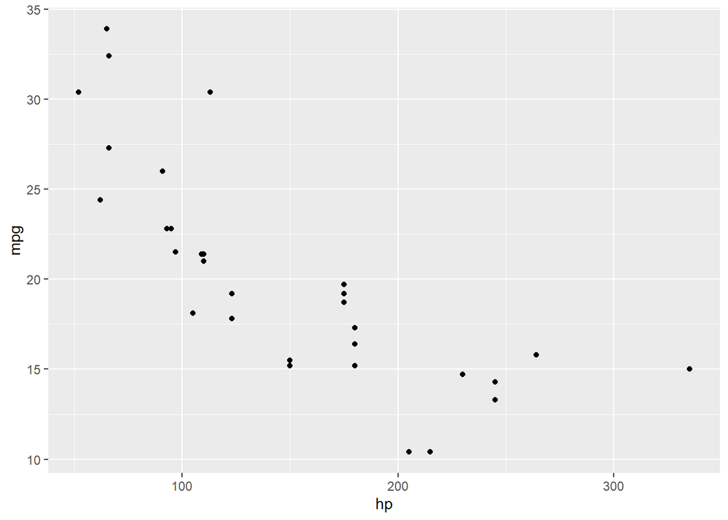

```r
library(ggplot2)

mtcars_data %>%  # what data?
  ggplot( aes(x = hp, y = mpg) ) + # what variables on the axes?
  geom_point() # what type of representation?
```

### 2.3.2 Larger dots, with colours

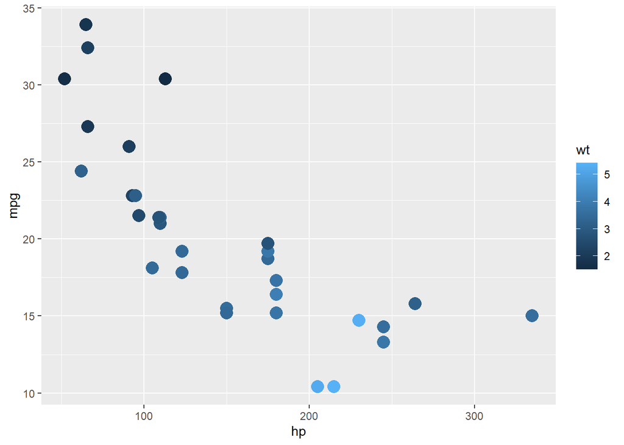

```r
mtcars_data %>%
  ggplot( aes(x = hp, y = mpg, colour = wt, size=2) ) +
  geom_point() +
  scale_size(guide = "none")
```

### 2.3.3 Adding a title and axes labels

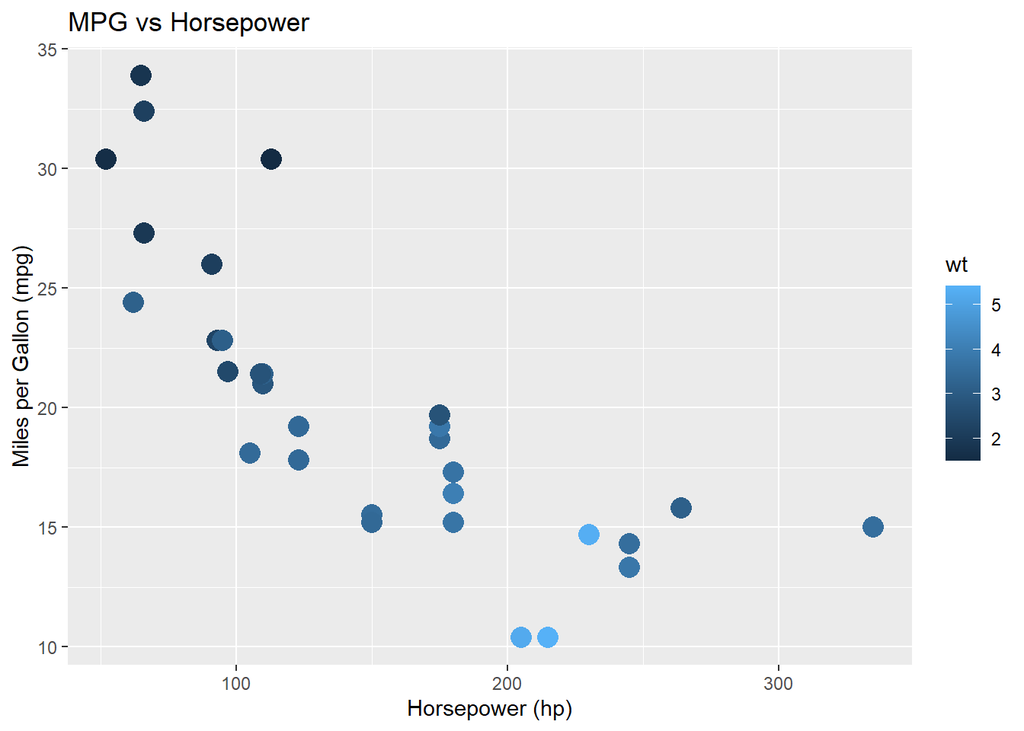

```r
mtcars_data %>%
  ggplot( aes(x = hp, y = mpg, colour = wt, size=2) ) +
  geom_point() +
  scale_size(guide = "none") +
  labs(title = "MPG vs Horsepower",
       x = "Horsepower (hp)",
       y = "Miles per Gallon (mpg)")
```

## 2.4 Take-home messages and final remarks

- There is always a (combination of) `dplyr` function(s) that can transform your data along your needs
- The `ggplot` (so-called) grammar of graphics is complex but highly consistent.
  - Learning a few basic rules will allow you to go a long way
  - Soon we will see how to make our R programmer lives easier with built-in `co-pilot` support and LLM requests
  - Please refrain using LLMs for the time being

## 2.5 In-class exercise

1. Load the data contained in the Excel file `iris.xlsx` in your R session. *(Hint: use function `read_excel()` of the R package `readxl` as in Session 1).*
2. Rename variable `Species` into `Species.name`. *(Hint: use function `rename()`, generic syntax: `data %>% rename(new_name = old_name)`)*
3. Create a new variable approximating the petal area as the product of petal length by petal width.
4. Create a simple scatter plot of sepal width against sepal length
5. Add species name as colors in the previous plot
6. Add a title and better formatted axis labels

## 2.6 Self-study exercise

- Select a simple dataset belonging to one of your current or past project (simple enough to consist of a single rectangular table).
- Load this dataset in R.
- Write instructions based on `filter, arrange, select, mutate` respectively.
- Create a simple and nice looking scatter plot.

## 2.7 External resource

- [Introduction to dplyr](https://cloud.r-project.org/web/packages/dplyr/vignettes/dplyr.html)
- [dplyr cheat sheet](https://github.com/rstudio/cheatsheets/blob/main/data-transformation.pdf)